# Introduction

Scientific question: Are there similarities between cytochrome P450 enzymes that are most commonly involved in drug metabolism pathways but are from different CYP families (CYP1A2, CYP2C9, CYP2C19, CYP2D6, CYP3A4, and CYP3A5)?

The cytochrome P450 enzymes are a superfamily of monooxygenase enzymes that are essential for drug metabolism (Tuomela et al., 2011). The P450 enzymes can be inhibited or induced by drugs, and there functions and interactions with them have been widely studied. There are over 50 enzymes in this class, but 90 percent of drugs are metabolized by six specific enzymes - CYP1A2, CYP2C9, CYP2C19, CYP2D6, CYP3A4, and CYP3A5. These enzymes are found mainly in the liver, but also in the small intestine, lungs, placenta, and kidneys (Lynch et al., 2007). The US FDA has included the P450 enzymes in lableing of drugs such as diazepam, codeine, propranolo, tetrabenzanine, fluoxetine, etc. (Shankar et al., 2014). Another study found that the most common pathways of prescription drug metabolism involved CYP3A4/5, CYP2C9, CYP2D6, and CYP2C19, and CYP enzymes from families 1, 2, or 3 (McDonnell 2013). Of these enzymes, the ones that come from the same family, such as CYP3A4 and CY3A5 from the 3A family, will have similarities in structure and sequence. So the focus will be the comparison between enzymes of different families in order to find structural or sequential similarities, which might suggest why these are the enzymes most common in drug metabolism. The fasta file I created includes 13 of the cytochrome enzymes that are involved in drug metabolism pathwaysL (CYP1A1, CYP1A2, CYP1B1, CYP2A6, CYP2C8, CYP2C9, CYP3A4, CYP3A5, CYP2D6, CYP2C19, CYP2E1, CYP2B6, CYP2J2)

Hypothesis: If there are similarities in sequence and structure between CYP1A2, CYP2C9, CYP2C19, CYP2D6, CYP3A4, and CYP3A5 excluding comparison between enzymes of the same familiy, then that would suggest why these are the most common drug metabolizing enzymes.

Pairwise sequence alignment was performed between each pair of proteins to compare two sequences for their similarity. The sequences for the proteins of interested were found from Uniprot, then downloaded into a FASTA file. The alignment scores obtained from the sequence alignment was put into a matric and a heatmap was used to visualize the scores. Homology modeling was used to compare the 3D structures of the proteins, specifically CYP1A2 and CYP3A4, and this was done in Swiss-model. Pymol was used to visualize the structural differences. The sequences of these enzymes can be found on uniprot (https://www.uniprot.org/) then combined into a single fasta file, and the structures can be found from RCSB (https://www.rcsb.org/) and downloaded as a pdb file.

# Loading in packages

SeqIO: an interface in BioPython that is used to input and output sequences. It can read, write, and index a variety of file formats including clustal, embl, fasta, swiss, uniprot-xml, etc.

numpy: a package that contains random number generators, arrays and matrices, and other mathematical functions.

matplotlib.pyplot: this package is used to create plots to visualize data. There are different functions that include plotting lines, creating axes labels, ticks, area, etc.

pairwise2: this is used for pairwise sequence alignment and provides functions for global and local alignments between two sequences.

Seq: This turns a sequence to a read-only sequence object. It also provides string like methods as well as biological methods, such as complement, reverse_complement, transcribe, and translate.

pandas: This package is useful for data manipulation and analysis. It provides data structures and operations for manipulating numerical tables. It allows large data sets to be analyzed and manipulated.

seaborn: this is used for data visualization and is based on matplotlib, and is used for making statistcal graphs. Compared to matplotlib, seaborn works better with pandas dataframes.

```python
from Bio import SeqIO
import numpy as np
import matplotlib.pyplot as plt
from Bio import pairwise2
from Bio.Seq import Seq
import pandas as pd
import seaborn as sns
```

# Performing bioinformatics analysis

#### Pairwise sequence alignment

Pairwise sequence alignment is used to identify regions of similarity between two sequences. This may indicate any functional, structural and/or evolutionary relationships between the two sequences. To perform pairwise sequence alignment, a FASTA file containing the sequences is first read in. Each sequence begins with a single-line description starting with ">" and is folllowed by the sequence data, which can be sequences of nucleotides or amino acids. The code below loads in a fasta file containing the sequences of the cytochrome P450 proteins of interest (CYP1A1, CYP1A2, CYP1B1, CYP2A6, CYP2C8, CYP2C9, CYP3A4, CYP3A5, CYP2D6, CYP2C19, CYP2E1, CYP2B6, CYP2J2). These sequences are amino acid sequences.

```python
# Read in the fasta file using SeqIO
#define the global variable Fasta
Fasta = [i for i in SeqIO.parse("cyp_p450.fasta", "fasta")]

#code check for length, the number of sequences in the fasta file
print(len(Fasta))
#code check - prints the name of the first sequence in the file
print(Fasta[0].name)

# define the global variable size
size = len(Fasta)

#define the global variable alignments_score
#initiatea an empy numpy matrix that is the length of the fasta file
alignments_score = np.empty(shape=(size,size))
```

```
13
sp|P04798|CP1A1_HUMAN
```

```python
#create function to perform pairwise sequence alignment
def pairwise_seq(my_array, size):
    #Nested for loop to do pairwise sequence alignment for each pair
    # loop over the proteins
    for i in range(size):
        # loop over the proteins again
        for j in range(size):
        # Define local variables X and Y, the two sequences to be aligned
            X = Fasta[i].seq
            Y = Fasta[j].seq
            #Code Check to see that the sequence pairs were succesfully created
            print(Fasta[i].id)
            print(Fasta[j].id)
            print(' ')

            #define a local variable my_array to contain alignment scores
            my_array[i,j] = int(pairwise2.align.globalxx(X, Y, score_only=True))

    #returns the array created
    return my_array

#define global variable My_scores to use the function defined above and create a matrix
My_scores = pairwise_seq(alignments_score, size)
print(My_scores)
```

```
sp|P04798|CP1A1_HUMAN
sp|P04798|CP1A1_HUMAN

sp|P04798|CP1A1_HUMAN
sp|P05177|CP1A2_HUMAN

sp|P04798|CP1A1_HUMAN
sp|Q16678|CP1B1_HUMAN

sp|P04798|CP1A1_HUMAN
sp|P11509|CP2A6_HUMAN

sp|P04798|CP1A1_HUMAN
sp|P10632|CP2C8_HUMAN

sp|P04798|CP1A1_HUMAN
sp|P11712|CP2C9_HUMAN

sp|P04798|CP1A1_HUMAN
sp|P08684|CP3A4_HUMAN

sp|P04798|CP1A1_HUMAN
sp|P20815|CP3A5_HUMAN

sp|P04798|CP1A1_HUMAN
sp|P10635|CP2D6_HUMAN

sp|P04798|CP1A1_HUMAN
sp|P33261|CP2CJ_HUMAN

sp|P04798|CP1A1_HUMAN
sp|P05181|CP2E1_HUMAN

sp|P04798|CP1A1_HUMAN
sp|P20813|CP2B6_HUMAN

sp|P04798|CP1A1_HUMAN
sp|P51589|CP2J2_HUMAN

sp|P05177|CP1A2_HUMAN
```

[output cut: 465 more lines]

```
sp|P51589|CP2J2_HUMAN

[[512. 380. 246. 223. 216. 218. 210. 211. 222. 218. 219. 216. 214.]
 [380. 516. 255. 208. 210. 211. 202. 208. 226. 213. 214. 216. 215.]
 [246. 255. 543. 212. 221. 223. 209. 205. 231. 221. 213. 231. 215.]
 [223. 208. 212. 494. 269. 270. 202. 201. 242. 277. 274. 286. 248.]
 [216. 210. 221. 269. 490. 387. 204. 205. 243. 387. 299. 276. 252.]
 [218. 211. 223. 270. 387. 490. 210. 212. 242. 449. 300. 269. 252.]
 [210. 202. 209. 202. 204. 210. 503. 426. 201. 208. 213. 204. 210.]
 [211. 208. 205. 201. 205. 212. 426. 502. 201. 210. 206. 211. 207.]
 [222. 226. 231. 242. 243. 242. 201. 201. 497. 240. 243. 244. 259.]
 [218. 213. 221. 277. 387. 449. 208. 210. 240. 490. 298. 262. 252.]
 [219. 214. 213. 274. 299. 300. 213. 206. 243. 298. 493. 267. 247.]
 [216. 216. 231. 286. 276. 269. 204. 211. 244. 262. 267. 491. 252.]
 [214. 215. 215. 248. 252. 252. 210. 207. 259. 252. 247. 252. 502.]]
```

# Plotting the results

The code below uses Matplotlib to create a heatmap. A heatmap is a data visualization technique that shows magnitude of a phenomenon as color in a two dimensional plot. Here we are using a heatmap to compare the alignment scores obtained from the pairwise sequence alignment for each pair of sequences. The x and y axes ticks and a color bar is added, and the plot is shown.

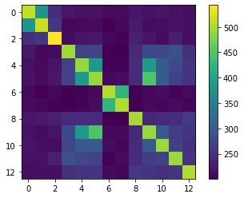

```python
#Create subplot
fig, ax = plt.subplots()

# Actually show the heatplot
plt.imshow(alignments_score)

# Construct the heat map to show the axes
im = ax.imshow(alignments_score)

# Add a colorbar to the right of the heatmap
cbar = ax.figure.colorbar(im)

# Show the plot
plt.show()
```

# Analysis of the results

#### Heatmap analysis

The heatmap above shows the pairwise sequence alignment scores between each pair of sequences. The x and y axes ticks are labeled, with tick 0 being the first sequence in the file, tick 1 being the second sequence, and so on. Each cell represents an alignment scores, with the color corresponding to the color bar on the right. The color bar shows the ranges of the alignment scores - sequences that have higher alignment scores are closer to yellow (>500), and sequences that have lower alignment scores are closer to dark blue (<250).

The diagonal line of yellow/green shows high alignment scores, which is expected because these are aligning a sequence with itself. The majority of the alignment scores between each pair of sequences show a cell that is dark blue, with an alignment score of approximately less 300 or less. There are several pairs of sequences that are similar to each other which are:

0 , 1 --> CYP1A1 , CYP1A2

4 , 5 --> CYP2C8 , CYP2C9

6 , 7 --> CYP3A4 , CYP3A5

4 , 9 --> CYP2C8 , CYP2C19

5 , 9 --> CYP2C9 , CYP2C19

This grouping shows that the CYP enzymes within the same numeric family have high alignment scores, but that enzymes from different families have low scores. For example, the alignment between CYP1A2 (tick 1) and CYP3A4 (tick 6) shows a dark blue/purple cell, corresponding to an alignment score of less than 250. Sinnce CYP1A2 and CYP3A4 are highly active metabolizing enzymes, one would expect similarities, but this pair has one of the lowest alignment scores present in the heatmap. My hypothesis was incorrect because there are no similarities between the primary drug metabolizing enzymes across families.

#### Homology modeling analysis

Homology modeling was performed using Swiss-model. Homology modeling is a method of visualizing the three-dimensional structure of a protein in order to compare them. Here, I chose to compare CYP1A2 and CYP3A4, two of the primary metabolizing enzymes that come from different families. The heatmap analyses above showed that the pairwise sequence alignment between CYP1A2 and CYP3A4 had a very low score of less than 250, so doinng the homology model for these would also show structural differences.

In Swiss-model, the sequence of CYP1A2 was inputed, as well as a pdb file of CYP3A4 crystal structure (1W0G) from RCSB. The figures obtained from the model results are shown below.

[figure not shown]

The figure below shows the model-template alignment between the sequence of CYP1A2 that was inputed in the top row Model_01, and the sequence of the 1W0G.pdb as template_upload.1.A. The arrows show secondary structures and the circles shows alpha-helices. There are very few similarities in the sequences of CYP1A2 vs CYP3A4.

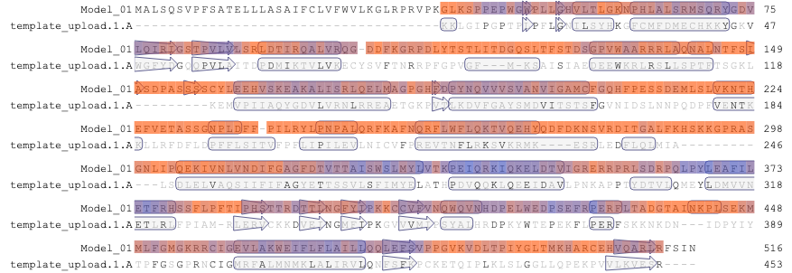

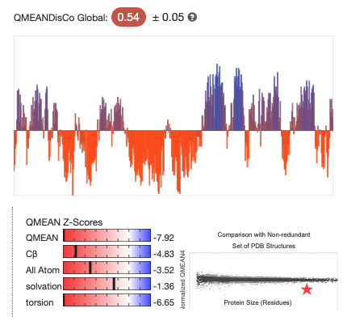

The figure below shows a Ramachandran plot. Ramachandran plots show the torsional angles - phi (φ)and psi (ψ) - of the residues in a peptide. It is used as a way to visualize the energetically allowed regions for the backbone dihedral angles. The top left region near 180 degrees with a large cluster of points show beta-sheets. Below thatis the right-handed alpha-helix. On the right hand side of the plot, the middle region of the y-axis shows the left-handed alpha-helix.

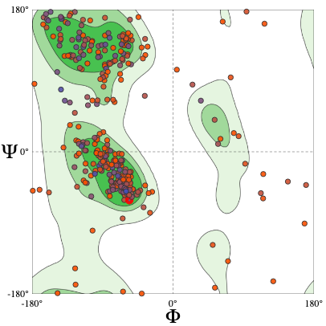

The homology model was also visualized in PyMOL. The movie created in PyMOL is linked below, and shows the homology model between CYP1A2 and the CYP3A4 template, and zooms in on several differences in their structures. The homology model is shown in green, the CYP3A4 template is shown in cyan, and the CYP1A2 is shown in magenta. The movie zooms in on several differences between the homology model and the CYP3A4 template.

```python
#to embed a youtube video
from IPython.display import YouTubeVideo
YouTubeVideo('sIhZQJG-P6o', width=800, height=300)
```

[video not shown]

The homology model analysis showed that the structures of CYP1A2 and CYP3A4 are not similar, as shown by the 3D structure, QMEAN score, and model-template sequence alignment. I can conclude from this that my hypothesis was incorrect, and that the cytochrome p450 enzymes across different families are not similar in structure and sequence.